# 2 - Explore Data

WWagner

2025-03-29

# 1. Introduction

This guide focuses on developing a basic understanding of the most common R operators, review the logic of R code, and apply it through initial exploration of data.

# 2. Getting Started: Operators, Symbols, Coding Logic

Let us get familiar with specific symbols and their meaning in R. Once you understand this basic logic of R as a language, you will be able to find help in forums or via ChatGPT but you will be able to understand the output.

The `<-` operator ‘assigns’ content to any object. This object can be an existing or new data frame, it could be a single variable, a vector or list, or even the column name of a specific column in the dataset (which you will learn about in tutorial 3).

The `$` operator ‘connects’ a dataframe to a variable within it. For example, your command calls the column ‘myname’ in the dataframe ‘newdata’ using this command `newdata$myname`. You will see this appear in a host of functions where we plot, summarize or manipulate columns, recode column names, or filter based on specific columns.

The `[]` (square brackets) serve another important purpose in R: they function as IF statements. Square brackets contain a condition (for example for filtering or recoding variables or individual observations). We will soon use this logic in recoding missing values into `NA`. For example, the following code `mydata$myvariable[mydata$myvaribale==-99]<-NA` essentially says go to myvariable and IF myvariable has the value -99, then replace this value with NA. Also not the use of double equal signs to signify the equality. Similarly we could use inequalities such as `!=` for NOT equal, or `<=` and `>=` operators for numeric variables.

The `[]` can also be used to subset the data, either by columns or by rows, indicated by the particular placing of a comma within the square brackets. For example, `mtcars2[,"cylinder"]` will return the values of the column called ‘cylinder’. Therefore, selecting columns is preceded by a comma. Instead, the code `mtcars2[mtcars2$cylinder=="6 Cylinder",]` returns all observations that match this conditions. Therefore, subsetting rows is done by a condition followed by a comma. Just remember `[rows, columns]`.

You will frequently see the tilde `~` symbol in our code. In common terms, the `~` can be translated as the word “by”. For example, in a bivariate regression we write the y is explained by x through the statement `y~x`. Other times we might want to plot the distribution of a continuous variable “by” the categories of another variable and might state `data$variable1 ~ data$variable2`.

Finally, you will come across the pipe symbol `%>%`. It is part of the tidyverse environment and used to combine multiple operations:

```r
newdata <- olddata %>%      # This line states that the operations will be applied to "olddata" and saved in a new dataset
  mutate(newvariable = variable1 + variable2)  # This line creates a new variable by combining 2 existing ones
```

# 3. Explore Data

Let us move on to exploring some data. In the previous guide, you learned how to work with packages (load `library`), how to setup your working directory, and how to import and export data.

When starting to work with a dataset, it is best to prepare data in the following stages:

1. Review the names of the variables (columns) in your dataset.
2. Briefly review the data itself.
3. Produce a frequency table of each variable of interest.
4. Explore data visually.
5. Declare missing values.
6. Declare correct levels of measurement for each variable of interest (possibly assign labels to categories).
7. Complete your main data analysis.

Move along on your own with the following steps to get familiar with the data:

```r
# Load the dataset iris, which exists within R for easy download like so:
data("iris")
# Lets start by reviewing the variables in this dataset
names(iris)
```

```
## [1] "Sepal.Length" "Sepal.Width"  "Petal.Length" "Petal.Width"  "Species"
```

The command `names` shows us all column and therefore variable names included in this data. We first observe that the dataset includes five variables, including measurements in centimeters of the variables ‘sepal length’, ‘sepal width’, ‘petal length’ and ‘petal width’, respectively, for 50 flowers from each of 3 species of iris. The species are Iris setosa, versicolor, and virginica.

## 3.1 Briefly Review Data

Every project should begin by thoroughly investigating and familiarizing yourself with the data set - what variables are included, what do they mean, how are they measured (i.e. units), how many rows/observations are there, what does an individual row represent? Try running each of the following commands in R, using the iris dataset.

```r
dim(iris) # Gives us the rows x columns (size of the matrix)
head(iris) # gives us the top observations
head(iris, 20) # view the first 20 rows
tail(iris) # gives us the bottom observations
View(iris) # With capital V, opens the data viewer
```

## 3.2 Frequency Tables

Besides taking a good look at what is included in a dataset (the variables, number of observations etc.), we want to look at the frequency or distribution of central variables. Frequency tables are one way to summarize a variable. They reveal how many observations (rows) have been assigned to each category, within a variable:

```r
table(iris$Species)
```

```
##
##     setosa versicolor  virginica
##         50         50         50
```

**As you can see, we use a dollar sign $ to indicate a variable in the dataframe object.**

These do not work as well with continuous data, but can still be useful for a quick glance:

```r
table(iris$Sepal.Length)
```

```
##
## 4.3 4.4 4.5 4.6 4.7 4.8 4.9   5 5.1 5.2 5.3 5.4 5.5 5.6 5.7 5.8 5.9   6 6.1 6.2
##   1   3   1   4   2   5   6  10   9   4   1   6   7   6   8   7   3   6   6   4
## 6.3 6.4 6.5 6.6 6.7 6.8 6.9   7 7.1 7.2 7.3 7.4 7.6 7.7 7.9
##   9   7   5   2   8   3   4   1   1   3   1   1   1   4   1
```

Another important way to explore data uses cross-tabulation. Here we generate a table showing the counts of observations falling within categories of two variables. This makes most sense when both variables have categories, but can also illustrate variation across categories of one variable and one numerical variable. Try the following on your own:

```r
table(iris$Species, iris$Sepal.Length)
prop.table(table(iris$Species, iris$Sepal.Length),1) # gives us row percentages
prop.table(table(iris$Species, iris$Sepal.Length),2) # gives us column percentages
```

We can also use a summary command to receive information on ALL variables in our data, but this becomes messy quickly if you have a lot of variables:

```r
summary(iris)
```

```
##   Sepal.Length    Sepal.Width     Petal.Length    Petal.Width
##  Min.   :4.300   Min.   :2.000   Min.   :1.000   Min.   :0.100
##  1st Qu.:5.100   1st Qu.:2.800   1st Qu.:1.600   1st Qu.:0.300
##  Median :5.800   Median :3.000   Median :4.350   Median :1.300
##  Mean   :5.843   Mean   :3.057   Mean   :3.758   Mean   :1.199
##  3rd Qu.:6.400   3rd Qu.:3.300   3rd Qu.:5.100   3rd Qu.:1.800
##  Max.   :7.900   Max.   :4.400   Max.   :6.900   Max.   :2.500
##        Species
##  setosa    :50
##  versicolor:50
##  virginica :50
##
##
##
```

Now you can see an overview including some summary statistics of all five variables. Note that for factor variables (that is nominal variables) we only receive the number of observations as other statistics (such as mean, standard deviation) cannot be calculated for non-numerical vectors.

Another useful command comes from the package “purrr”:

```r
# install.packages("purrr")
library(purrr)   # make sure to do this only once at the beginning of the session
map(iris, table) # specify the data.frame, and then the function
```

```
## $Sepal.Length
##
## 4.3 4.4 4.5 4.6 4.7 4.8 4.9   5 5.1 5.2 5.3 5.4 5.5 5.6 5.7 5.8 5.9   6 6.1 6.2
##   1   3   1   4   2   5   6  10   9   4   1   6   7   6   8   7   3   6   6   4
## 6.3 6.4 6.5 6.6 6.7 6.8 6.9   7 7.1 7.2 7.3 7.4 7.6 7.7 7.9
##   9   7   5   2   8   3   4   1   1   3   1   1   1   4   1
##
## $Sepal.Width
##
##   2 2.2 2.3 2.4 2.5 2.6 2.7 2.8 2.9   3 3.1 3.2 3.3 3.4 3.5 3.6 3.7 3.8 3.9   4
##   1   3   4   3   8   5   9  14  10  26  11  13   6  12   6   4   3   6   2   1
## 4.1 4.2 4.4
##   1   1   1
##
## $Petal.Length
##
##   1 1.1 1.2 1.3 1.4 1.5 1.6 1.7 1.9   3 3.3 3.5 3.6 3.7 3.8 3.9   4 4.1 4.2 4.3
##   1   1   2   7  13  13   7   4   2   1   2   2   1   1   1   3   5   3   4   2
## 4.4 4.5 4.6 4.7 4.8 4.9   5 5.1 5.2 5.3 5.4 5.5 5.6 5.7 5.8 5.9   6 6.1 6.3 6.4
##   4   8   3   5   4   5   4   8   2   2   2   3   6   3   3   2   2   3   1   1
## 6.6 6.7 6.9
##   1   2   1
##
## $Petal.Width
##
## 0.1 0.2 0.3 0.4 0.5 0.6   1 1.1 1.2 1.3 1.4 1.5 1.6 1.7 1.8 1.9   2 2.1 2.2 2.3
##   5  29   7   7   1   1   7   3   5  13   8  12   4   2  12   5   6   6   3   8
## 2.4 2.5
##   3   3
##
## $Species
##
##     setosa versicolor  virginica
##         50         50         50
```

- This becomes very unruly with more variables though. We recommend doing this only for small data.frames, with relatively few variables. Later on we will see how to create a new data.frame, selecting only a few variables of interest.

# 4. Explore Data Visually (quick look)

Besides tables and summary statistics (the logic of which I will not cover here), we should always visualize our data to identify patterns, distributions, and even potential relationships. In base R, we have some simple functions to explore data visually. It is the benefit of the `plot` command in base R that it ‘chooses’ a most appropriate plot fo the underlying data ‘class’ (i.e. numeric, ordered, factor) - yet, this choice might not always be ideal.

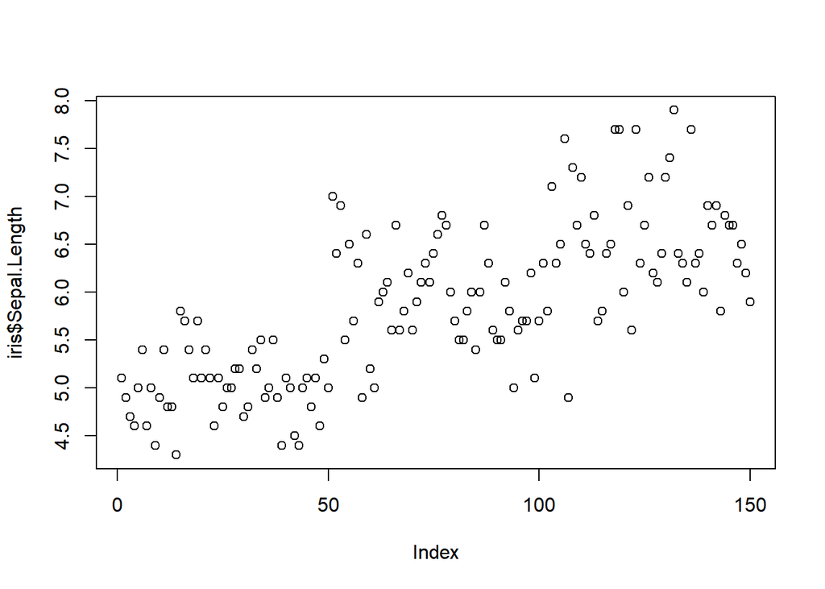

```r
plot(iris$Sepal.Length)
```

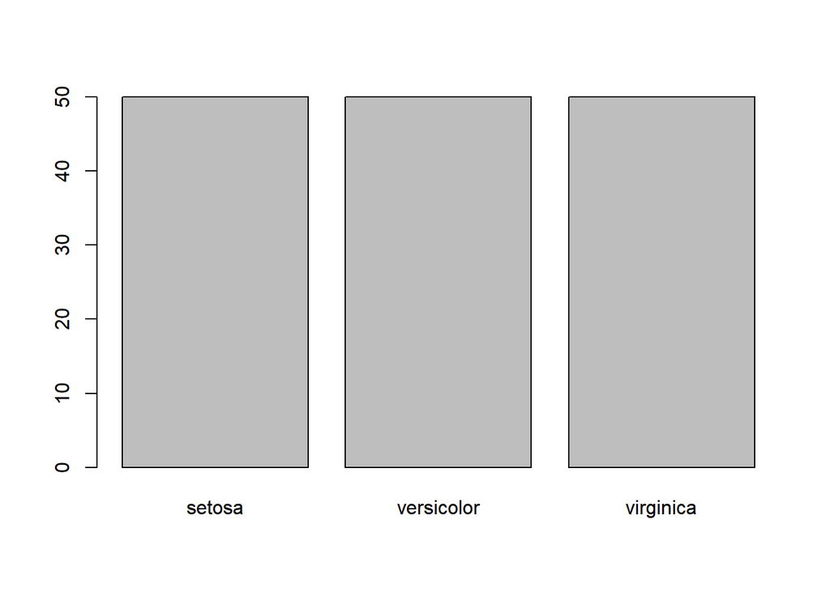

```r
plot(iris$Species)
```

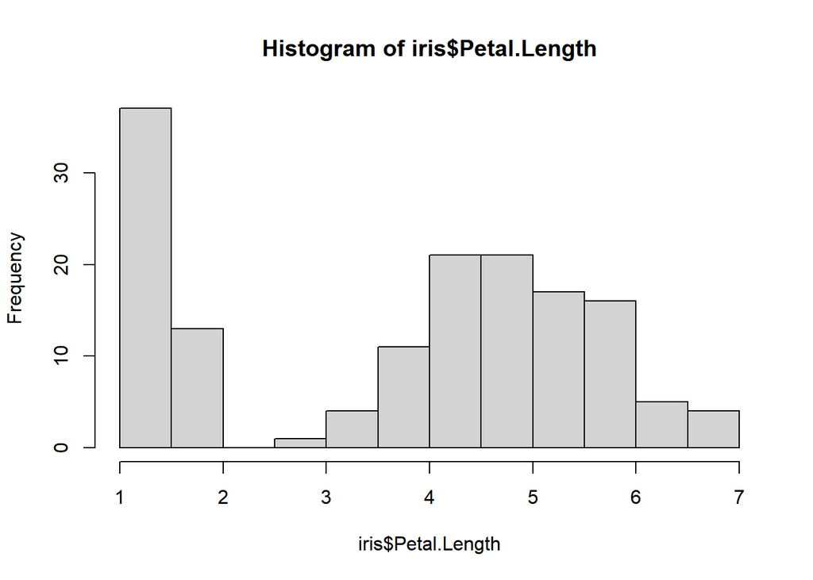

```r
hist(iris$Petal.Length)
```

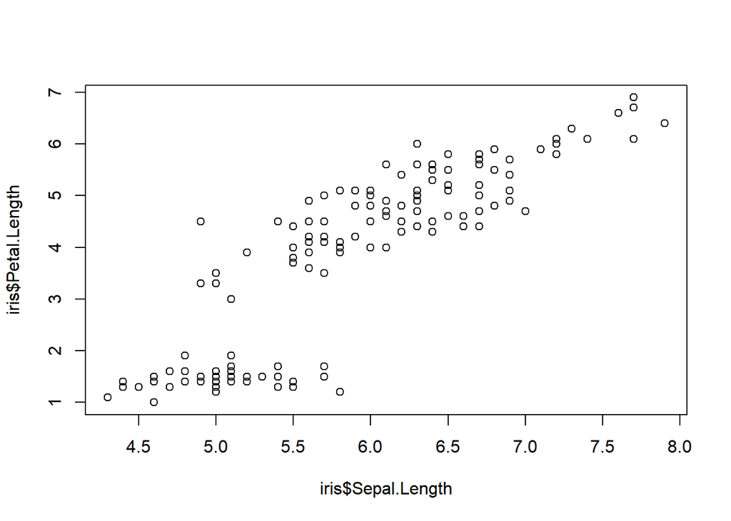

```r
plot(iris$Sepal.Length, iris$Petal.Length)
```

# 5. Conclusion

These functions can be useful to initially explore your data and understand what your data set includes. The benefit here is that Base R chooses the type of plot for you - based on its assessment of the underlying data structure. Thus it will choose different plots for categorical versus numerical data.

- Following the initial data exploration, our next step in R will be data manipulation. Before moving on to more ‘fancy’ data visualization, we will learn to clean, reorganize, and categorize data in the next tutorial.